# experiment

> 运行项目

```
cd /root/final_MSME
python train.py # 指定model单次运行
python run.py # 所有model运行多重实验
```

```python
import sys
print(sys.version)
import torch_geometric
print(torch_geometric.__version__)
import torch
torch.version.cuda
```

```
3.8.10 (default, Jun  4 2021, 15:09:15)
[GCC 7.5.0]
2.6.1
```

```
'11.8'
```

## 1. data预处理和介绍

- **脑图A1：`../multidata/fMRI/`，这是fmri相关性矩阵，90,90，txt，每个节点记为ROI，以下所言的节点、脑区、ROI指代一个东西**
- 脑图A2：`../abide1/`，这是fmri相关性矩阵，160,160，txt，每个节点记为ROI，以下所言的节点、脑区、ROI指代一个东西
- **特征X备选1：`../multidata/DTI/`，这是dti数据 90,90，txt**
- 特征X备选2：`../multidata/sMRI/`，这是smri数据，90,90，txt
- 特征X备选3：`../timecourse/`，这是关于fmri的时间序列数据，160,N，txt，要处理成彼此间的偏相关系数阵作为特征，最后应为 90,90。
- **形式1：A和备选X命名均为 ‘N10002.txt’ 类似格式，即 字母N + 1或2 + 4位数字编号**
  - 记命名中第二位字符为类别编号，1类和2类（患病和正常）
  - 按命名匹配被试，要求一个被试要同时有A X
- 形式2：A命名为 ‘ASD50182.txt’ 类似格式，即 字母ASD或TC + 5位数编号
  - 命名含ASD记为患病类别，否则记为正常类别
- 对A做归一化，使A的各值均在0到1之间，反映为绝对功能连接强度
- **节点位置信息以及子网络信息在模版文件，使用的是AAL90模版：`aal90.csv`，包含：脑区编号、脑区名、绝对坐标、脑区体素数、子网络功能区分类-5类（又称系统、社区）、子网络解剖区分类-6类** 前几行信息：

```
  Labels	Regions	x(mm)	y(mm)	z(mm)	# of voxels within ROIs	Functional classification		Anatomical classification
    1	Precentral_L	-38.65 	-5.68 	50.94 	1028	Primary		Frontal
    2	Precentral_R	41.37 	-8.21 	52.09 	1002	Primary		Frontal
    3	Frontal_Sup_L	-18.45 	34.81 	42.20 	1076	Association	Heteromodal	Prefontal
    4	Frontal_Sup_R	21.90 	31.12 	43.82 	1159	Association	Heteromodal	Prefontal
    5	Frontal_Sup_Orb_L	-16.56 	47.32 	-13.31 	292	Paralimbic		Prefontal
```

- 采用脑图A1 形式1 模版信息选择Labels、x、y、z、体素数（更名为voxels）、Anatomical classification，特征X备选1、2分别匹配，根据匹配结果选择哪个特征（DTI）
- Anatomical classification

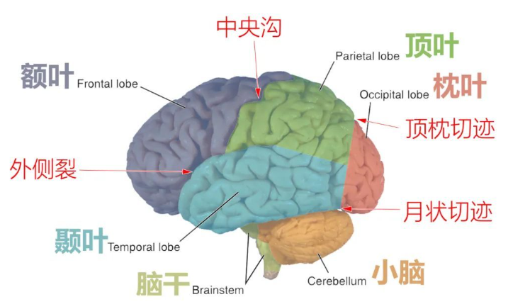

> ASD（自闭症谱系障碍）是一类神经发育疾病，其表现与脑功能连接的多尺度异常密切相关。

> 我们希望构建具备解剖先验、空间扰动建模和多尺度特征融合能力的图神经网络（GNN）模型，提升 ASD 的辅助诊断准确率与解释能力。

### 总体结构

- **输入**：90 节点功能连接图（fMRI）、节点特征（DTI）、空间坐标与解剖分区
- **结构组成**：
  - 系统 $B_k$：引入可学习解剖分区先验
  - 扰动 $\Delta_j$：基于节点三维坐标及邻域信息生成
  - 传播权重 $W_j = B_k + \Delta_j^{\text{exp}}$：实现个性化调制
  - GATv2Conv + Top-K Pooling
  - 多策略全局池化 + MLP 分类器

### 模型公式

1. 解剖嵌入： $$ B_k^{(l)} = \text{Embed}_{anat}(c_j^{(l)}) $$
2. 空间扰动向量： $$ e_j^{(l)} = W_{pos}^{(l)} p_j + b_{pos}^{(l)} $$
3. 邻域扰动编码： $$ \tilde{e}_j^{(l)} = \sum_{i \in \mathcal{N}(j) \cup \{j\}} A_{ij}^{(l)} e_i^{(l)} $$
4. 节点扰动： $$ \Delta_j^{(l)} = \tilde{e}_j^{(l)T} B_k^{(l)} $$
5. 节点传播： $$ W_j^{(l)} = B_k^{(l)} + \Delta_j^{(l)T} \Delta_j^{(l)} $$
6. 信息调制与GATv2聚合： $$ 注意力分数： {e}_{ij}=a^T LeakyReLU(W\left[m_j\middle|\left|m_i\right]\right)\\ 归一化： \alpha_{ij}=softmax_i\left(e_{ij}\right)=\frac{exp\left(e_{ij}\right)}{\sum_{k} e x p\left(e_{kj}\right)}，k\in\mathcal{N}_{\left(j\right)}\cup\{j\}\\ 更新： h_j^{\left(l\right)}=\sigma\left(\sum_{i\in N_{\left(j\right)}\cup\{j\}}{\alpha_{ij}m_i^\prime}\right)=\sigma\left(\sum_{i\in N_{\left(j\right)}\cup\{j\}}{\alpha_{ij}W}m_i\right) $$

### 实验

[output not shown]

### 解释性分析

1. 脑区扰动对比（ASD vs HC）
- **共同模式**：额叶与枕叶扰动大，皮层下区域扰动小
- **显著差异**：
  - 皮层下区域相对扰动增幅高达 **62.27%**
  - ASD 中高扰动区域：脑岛、扣带回、杏仁核、海马旁回
2. 高扰动节点分析

| 群体 | ROI | 解剖区域 |
| --- | --- | --- |
| ASD | 左脑岛、杏仁核、右中扣带回 | 皮层下、颞叶、额叶 |
| HC | 距状裂区、后扣带回、楔叶 | 枕叶、顶叶 |

### 缺点反思

- delta的区域意义：分级——再考虑解释性
- 特征还原：画热力
- 前端：专业性，面向医生，（专业用户视角）输入fmri，dti数据，根据模型输出诊断结果——可读性报告
- 加强框架解释性
- 前面放结果（解释性问题）：专攻扰动项节点
- 对比医疗报告，指出不足
- demo设计

### 拓展方向

- 多中心验证实验
- 应用于其他神经精神障碍（如 AD、SZ）
- 融合时间序列与动态连接建模
- 推进临床可解释性工具的开发

```python
import os
import numpy as np
import pandas as pd
from glob import glob
from collections import defaultdict

# 路径定义
fmri_path = "../multidata/fMRI/"
dti_path = "../multidata/DTI/"
smri_path = "../multidata/sMRI/"
template_path = "aal90.csv"
# 加载模板信息
template = pd.read_csv(template_path)
# 提取所需列
template = template[['Labels', 'x(mm)', 'y(mm)', 'z(mm)', '# of voxels within ROIs', 'Anatomical classification']]
# 重命名列
template.columns = ['Labels', 'x', 'y', 'z', 'voxels', 'Anatomical_classification']
# 获取所有fMRI文件
fmri_files = glob(os.path.join(fmri_path, "zN*.txt"))
```

```python
# 创建匹配字典
subjects = defaultdict(dict)
for fmri_file in fmri_files:
    subject_id = os.path.basename(fmri_file)
    # 存储完整文件名作为fMRI路径
    subjects[subject_id]['fmri'] = fmri_file
    subjects[subject_id]['class'] = int(subject_id[2])  # 第3位表示类别

# 匹配DTI和sMRI文件（它们没有z前缀）
for subject_id in list(subjects.keys()):
    # 提取基本ID（去掉z前缀，用于匹配DTI和sMRI文件）
    base_id = subject_id[1:]  # 去掉z前缀

    dti_file = os.path.join(dti_path, base_id)
    smri_file = os.path.join(smri_path, base_id)

    if os.path.exists(dti_file):
        subjects[subject_id]['dti'] = dti_file

    if os.path.exists(smri_file):
        subjects[subject_id]['smri'] = smri_file

    # 如果既没有DTI也没有sMRI，则删除该被试
    if 'dti' not in subjects[subject_id] and 'smri' not in subjects[subject_id]:
        del subjects[subject_id]

# 统计DTI和sMRI匹配成功的数量
dti_count = sum(1 for s in subjects.values() if 'dti' in s)
#smri_count = sum(1 for s in subjects.values() if 'smri' in s)
smri_count = 0

print(f"总共匹配到 {len(subjects)} 个被试")
print(f"DTI匹配成功: {dti_count} 个被试")
print(f"sMRI匹配成功: {smri_count} 个被试")

# 选择匹配率更高的特征
feature_type = 'dti' if dti_count >= smri_count else 'smri'
feature_path = dti_path if feature_type == 'dti' else smri_path
print(f"选择 {feature_type.upper()} 作为特征")

# 处理数据
X = []            # 特征矩阵（3D数组，每个为90×90）
A = []            # fMRI邻接矩阵（归一化后）
y = []            # 类别标签
subject_ids = []  # 被试ID

for subject_id, data in subjects.items():
    if feature_type in data:
        try:
            # 加载并归一化fMRI数据（邻接图）
            fmri_matrix = np.loadtxt(data['fmri'])
            fmri_min = fmri_matrix.min()
            fmri_max = fmri_matrix.max()
            if fmri_max != fmri_min:
                fmri_norm = (fmri_matrix - fmri_min) / (fmri_max - fmri_min)
            else:
                fmri_norm = fmri_matrix  # 避免除以零

            # 加载DTI或sMRI特征（90×90）
            feature_matrix = np.loadtxt(data[feature_type])

            # 验证尺寸一致性
            if fmri_matrix.shape == (90, 90) and feature_matrix.shape == (90, 90):
                A.append(fmri_norm)            # 添加归一化后的fMRI邻接图
                X.append(feature_matrix)       # 不再flatten
                y.append(data['class'])
                subject_ids.append(subject_id)
            else:
                print(f"被试 {subject_id} 的数据维度不匹配，跳过。")
        except Exception as e:
            print(f"处理被试 {subject_id} 时出错: {e}")

# 转换为numpy数组
# 转换为numpy数组
X = np.array(X)  # [n_subjects, 90, 90]
A = np.array(A)  # [n_subjects, 90, 90]
y = np.array(y)

if len(X) > 0:
    print(f"最终数据集: {len(X)} 个被试, 特征维度: {X.shape[1:]}")  # 输出为 (90, 90)
    print(f"类别分布: 类别1 (患病): {np.sum(y == 1)}, 类别2 (正常): {np.sum(y == 2)}")

    # 保存处理后的数据
    results = {
        'X': X,                      # 特征矩阵
        'A': A,                      # 归一化后的fMRI邻接图
        'y': y,
        'subject_ids': subject_ids,
        'template': template,
        'feature_type': feature_type
    }

    # 保存为NumPy格式
    np.save('processed_brain_data.npy', results)
    print("数据处理完成并保存")

    print("\n数据格式示例：")
    print('''{
        'X': 特征矩阵 [n, 90, 90]，来自 DTI ，
        'A': 邻接矩阵 [n, 90, 90]，来自归一化 fMRI相关阵，
        'y': 标签数组 [n]，
        'template': aal90 模板信息，
        'feature_type': 'dti'
    }''')
else:
    print("警告：没有成功处理任何数据，请检查文件路径和格式")
```

[output not shown]

## 2. 记录

### 2.1 version 1.0 截止5.14

> 非常粗糙的版本，扰动核位置嵌入映射和社区核结构先验几乎没有设计
- DTI

**训练指标**

```
2025-05-14 21:25:48,169 - training_logger - INFO - Model parameters: 11804
Model initialized with 6 brain systems and 3D position encoding on device cuda:0
2025-05-14 21:25:48,533 - training_logger - INFO - Epoch 001: Train Loss: 538.6753, Train Auc: 0.5977, Val Auc: 0.3636, Val F1: 0.3125
2025-05-14 21:25:48,597 - training_logger - INFO - Epoch 002: Train Loss: 537.1693, Train Auc: 0.5402, Val Auc: 0.4050, Val F1: 0.3125
2025-05-14 21:25:48,661 - training_logger - INFO - Epoch 003: Train Loss: 492.9394, Train Auc: 0.5632, Val Auc: 0.5000, Val F1: 0.3333
2025-05-14 21:25:48,721 - training_logger - INFO - Epoch 004: Train Loss: 513.5835, Train Auc: 0.4368, Val Auc: 0.5620, Val F1: 0.5686
2025-05-14 21:25:48,784 - training_logger - INFO - Epoch 005: Train Loss: 411.6537, Train Auc: 0.5057, Val Auc: 0.5000, Val F1: 0.3333
2025-05-14 21:25:49,039 - training_logger - INFO - Epoch 006: Train Loss: 397.6788, Train Auc: 0.5287, Val Auc: 0.5620, Val F1: 0.5455
2025-05-14 21:25:49,112 - training_logger - INFO - Epoch 007: Train Loss: 327.8368, Train Auc: 0.4598, Val Auc: 0.6818, Val F1: 0.5087
2025-05-14 21:25:49,181 - training_logger - INFO - Epoch 008: Train Loss: 286.0406, Train Auc: 0.5632, Val Auc: 0.5372, Val F1: 0.5089
2025-05-14 21:25:49,238 - training_logger - INFO - Epoch 009: Train Loss: 269.3242, Train Auc: 0.5632, Val Auc: 0.5289, Val F1: 0.5686
2025-05-14 21:25:49,303 - training_logger - INFO - Epoch 010: Train Loss: 255.2129, Train Auc: 0.5057, Val Auc: 0.4628, Val F1: 0.3333
2025-05-14 21:25:49,553 - training_logger - INFO - Epoch 011: Train Loss: 249.3012, Train Auc: 0.5172, Val Auc: 0.4380, Val F1: 0.3333
2025-05-14 21:25:49,620 - training_logger - INFO - Epoch 012: Train Loss: 229.0814, Train Auc: 0.5632, Val Auc: 0.4545, Val F1: 0.4271
2025-05-14 21:25:49,698 - training_logger - INFO - Epoch 013: Train Loss: 225.9891, Train Auc: 0.4828, Val Auc: 0.4215, Val F1: 0.4271
2025-05-14 21:25:49,771 - training_logger - INFO - Epoch 014: Train Loss: 225.8490, Train Auc: 0.5747, Val Auc: 0.6198, Val F1: 0.3333
2025-05-14 21:25:49,835 - training_logger - INFO - Epoch 015: Train Loss: 226.3898, Train Auc: 0.4943, Val Auc: 0.5661, Val F1: 0.3995
2025-05-14 21:25:50,177 - training_logger - INFO - Epoch 016: Train Loss: 225.7446, Train Auc: 0.5747, Val Auc: 0.5455, Val F1: 0.3333
2025-05-14 21:25:50,253 - training_logger - INFO - Epoch 017: Train Loss: 225.8293, Train Auc: 0.5747, Val Auc: 0.5455, Val F1: 0.3333
Epoch 00018: reducing learning rate of group 0 to 5.0000e-04.
2025-05-14 21:25:50,327 - training_logger - INFO - Epoch 018: Train Loss: 225.7183, Train Auc: 0.5747, Val Auc: 0.5455, Val F1: 0.3333
2025-05-14 21:25:50,395 - training_logger - INFO - Epoch 019: Train Loss: 225.7934, Train Auc: 0.5862, Val Auc: 0.5455, Val F1: 0.3333
2025-05-14 21:25:50,457 - training_logger - INFO - Epoch 020: Train Loss: 225.7280, Train Auc: 0.5632, Val Auc: 0.5000, Val F1: 0.3333
2025-05-14 21:25:50,792 - training_logger - INFO - Epoch 021: Train Loss: 225.7476, Train Auc: 0.5862, Val Auc: 0.5000, Val F1: 0.3333
2025-05-14 21:25:50,872 - training_logger - INFO - Epoch 022: Train Loss: 225.7262, Train Auc: 0.5747, Val Auc: 0.5000, Val F1: 0.3333
2025-05-14 21:25:50,946 - training_logger - INFO - Epoch 023: Train Loss: 225.7421, Train Auc: 0.5862, Val Auc: 0.5041, Val F1: 0.3333
2025-05-14 21:25:51,021 - training_logger - INFO - Epoch 024: Train Loss: 225.7346, Train Auc: 0.6092, Val Auc: 0.5041, Val F1: 0.4271
2025-05-14 21:25:51,103 - training_logger - INFO - Epoch 025: Train Loss: 225.7293, Train Auc: 0.5977, Val Auc: 0.5041, Val F1: 0.4271
2025-05-14 21:25:51,429 - training_logger - INFO - Epoch 026: Train Loss: 225.7331, Train Auc: 0.5747, Val Auc: 0.5537, Val F1: 0.4271
2025-05-14 21:25:51,495 - training_logger - INFO - Epoch 027: Train Loss: 225.7318, Train Auc: 0.5632, Val Auc: 0.5909, Val F1: 0.4271
2025-05-14 21:25:51,495 - training_logger - INFO - Early stopping at epoch 27
2025-05-14 21:25:51,495 - training_logger - INFO - Training completed. Evaluating best model on test set...
2025-05-14 21:25:51,512 - training_logger - INFO - ==================================================
Classification Report
==================================================
Accuracy: 0.4500
Precision: 0.4719
Recall: 0.4500
F1: 0.3987
Auc: 0.4242

2025-05-14 21:25:52,205 - training_logger - INFO - Starting fold 2/5
Model device check: cuda:0
2025-05-14 21:25:52,207 - training_logger - INFO - Model parameters: 11804
Model initialized with 6 brain systems and 3D position encoding on device cuda:0
2025-05-14 21:25:52,277 - training_logger - INFO - Epoch 001: Train Loss: 918.4386, Train Auc: 0.5402, Val Auc: 0.4959, Val F1: 0.3995
2025-05-14 21:25:52,342 - training_logger - INFO - Epoch 002: Train Loss: 874.5162, Train Auc: 0.4828, Val Auc: 0.5000, Val F1: 0.3333
2025-05-14 21:25:52,405 - training_logger - INFO - Epoch 003: Train Loss: 720.3241, Train Auc: 0.5057, Val Auc: 0.5909, Val F1: 0.4271
2025-05-14 21:25:52,472 - training_logger - INFO - Epoch 004: Train Loss: 624.0911, Train Auc: 0.5172, Val Auc: 0.5000, Val F1: 0.5299
2025-05-14 21:25:52,544 - training_logger - INFO - Epoch 005: Train Loss: 547.4721, Train Auc: 0.5632, Val Auc: 0.5537, Val F1: 0.4762
2025-05-14 21:25:52,801 - training_logger - INFO - Epoch 006: Train Loss: 483.9498, Train Auc: 0.5632, Val Auc: 0.5289, Val F1: 0.5089
2025-05-14 21:25:52,861 - training_logger - INFO - Epoch 007: Train Loss: 416.0975, Train Auc: 0.4598, Val Auc: 0.6570, Val F1: 0.5417
2025-05-14 21:25:52,922 - training_logger - INFO - Epoch 008: Train Loss: 269.4844, Train Auc: 0.5977, Val Auc: 0.6860, Val F1: 0.5810
2025-05-14 21:25:52,996 - training_logger - INFO - Epoch 009: Train Loss: 263.8860, Train Auc: 0.5977, Val Auc: 0.7107, Val F1: 0.6239
2025-05-14 21:25:53,073 - training_logger - INFO - Epoch 010: Train Loss: 230.6432, Train Auc: 0.4828, Val Auc: 0.6529, Val F1: 0.5299
2025-05-14 21:25:53,301 - training_logger - INFO - Epoch 011: Train Loss: 182.9227, Train Auc: 0.6207, Val Auc: 0.6570, Val F1: 0.5448
2025-05-14 21:25:53,364 - training_logger - INFO - Epoch 012: Train Loss: 177.1588, Train Auc: 0.6207, Val Auc: 0.6116, Val F1: 0.5089
2025-05-14 21:25:53,425 - training_logger - INFO - Epoch 013: Train Loss: 171.7767, Train Auc: 0.5287, Val Auc: 0.6364, Val F1: 0.6239
2025-05-14 21:25:53,488 - training_logger - INFO - Epoch 014: Train Loss: 161.4020, Train Auc: 0.6552, Val Auc: 0.7231, Val F1: 0.6758
2025-05-14 21:25:53,552 - training_logger - INFO - Epoch 015: Train Loss: 149.6642, Train Auc: 0.5172, Val Auc: 0.7190, Val F1: 0.5089
2025-05-14 21:25:53,789 - training_logger - INFO - Epoch 016: Train Loss: 143.5499, Train Auc: 0.5057, Val Auc: 0.5455, Val F1: 0.4905
2025-05-14 21:25:53,850 - training_logger - INFO - Epoch 017: Train Loss: 140.8720, Train Auc: 0.5172, Val Auc: 0.4793, Val F1: 0.4545
2025-05-14 21:25:53,911 - training_logger - INFO - Epoch 018: Train Loss: 139.4746, Train Auc: 0.4483, Val Auc: 0.3719, Val F1: 0.4762
2025-05-14 21:25:53,983 - training_logger - INFO - Epoch 019: Train Loss: 138.8703, Train Auc: 0.4253, Val Auc: 0.4876, Val F1: 0.3995
2025-05-14 21:25:54,060 - training_logger - INFO - Epoch 020: Train Loss: 138.7481, Train Auc: 0.4483, Val Auc: 0.5785, Val F1: 0.3995
2025-05-14 21:25:54,336 - training_logger - INFO - Epoch 021: Train Loss: 138.7430, Train Auc: 0.4368, Val Auc: 0.4959, Val F1: 0.3995
2025-05-14 21:25:54,401 - training_logger - INFO - Epoch 022: Train Loss: 138.7437, Train Auc: 0.4368, Val Auc: 0.4545, Val F1: 0.3125
2025-05-14 21:25:54,467 - training_logger - INFO - Epoch 023: Train Loss: 138.7703, Train Auc: 0.4253, Val Auc: 0.4545, Val F1: 0.3125
2025-05-14 21:25:54,545 - training_logger - INFO - Epoch 024: Train Loss: 138.7374, Train Auc: 0.4368, Val Auc: 0.4545, Val F1: 0.3125
Epoch 00025: reducing learning rate of group 0 to 5.0000e-04.
2025-05-14 21:25:54,606 - training_logger - INFO - Epoch 025: Train Loss: 138.7465, Train Auc: 0.4368, Val Auc: 0.4545, Val F1: 0.3125
2025-05-14 21:25:54,927 - training_logger - INFO - Epoch 026: Train Loss: 138.7365, Train Auc: 0.4368, Val Auc: 0.4545, Val F1: 0.3125
2025-05-14 21:25:55,000 - training_logger - INFO - Epoch 027: Train Loss: 138.7549, Train Auc: 0.4253, Val Auc: 0.4545, Val F1: 0.3125
2025-05-14 21:25:55,073 - training_logger - INFO - Epoch 028: Train Loss: 138.7563, Train Auc: 0.4253, Val Auc: 0.4545, Val F1: 0.3125
2025-05-14 21:25:55,142 - training_logger - INFO - Epoch 029: Train Loss: 138.7637, Train Auc: 0.4253, Val Auc: 0.4545, Val F1: 0.3125
2025-05-14 21:25:55,211 - training_logger - INFO - Epoch 030: Train Loss: 138.7464, Train Auc: 0.4368, Val Auc: 0.4545, Val F1: 0.3125
2025-05-14 21:25:55,520 - training_logger - INFO - Epoch 031: Train Loss: 138.7427, Train Auc: 0.4368, Val Auc: 0.4545, Val F1: 0.3125
2025-05-14 21:25:55,585 - training_logger - INFO - Epoch 032: Train Loss: 138.7577, Train Auc: 0.4253, Val Auc: 0.4545, Val F1: 0.3125
2025-05-14 21:25:55,654 - training_logger - INFO - Epoch 033: Train Loss: 138.7479, Train Auc: 0.4368, Val Auc: 0.4545, Val F1: 0.3125
2025-05-14 21:25:55,720 - training_logger - INFO - Epoch 034: Train Loss: 138.7533, Train Auc: 0.4253, Val Auc: 0.4545, Val F1: 0.3125
2025-05-14 21:25:55,721 - training_logger - INFO - Early stopping at epoch 34
2025-05-14 21:25:55,721 - training_logger - INFO - Training completed. Evaluating best model on test set...
2025-05-14 21:25:55,743 - training_logger - INFO - ==================================================
Classification Report
==================================================
Accuracy: 0.5000
Precision: 0.4733
Recall: 0.5000
F1: 0.4670
Auc: 0.5354
```

```
2025-05-14 21:25:56,422 - training_logger - INFO - Starting fold 3/5
Model device check: cuda:0
2025-05-14 21:25:56,423 - training_logger - INFO - Model parameters: 11804
Model initialized with 6 brain systems and 3D position encoding on device cuda:0
2025-05-14 21:25:56,489 - training_logger - INFO - Epoch 001: Train Loss: 300.7941, Train Auc: 0.4713, Val Auc: 0.7619, Val F1: 0.6919
2025-05-14 21:25:56,560 - training_logger - INFO - Epoch 002: Train Loss: 259.7579, Train Auc: 0.4713, Val Auc: 0.6476, Val F1: 0.6043
2025-05-14 21:25:56,625 - training_logger - INFO - Epoch 003: Train Loss: 235.3780, Train Auc: 0.5747, Val Auc: 0.6762, Val F1: 0.6869
2025-05-14 21:25:56,693 - training_logger - INFO - Epoch 004: Train Loss: 232.4680, Train Auc: 0.5402, Val Auc: 0.5238, Val F1: 0.2443
2025-05-14 21:25:56,765 - training_logger - INFO - Epoch 005: Train Loss: 235.2541, Train Auc: 0.5862, Val Auc: 0.7667, Val F1: 0.4907
2025-05-14 21:25:57,107 - training_logger - INFO - Epoch 006: Train Loss: 223.8710, Train Auc: 0.5172, Val Auc: 0.5905, Val F1: 0.5850
2025-05-14 21:25:57,171 - training_logger - INFO - Epoch 007: Train Loss: 217.9656, Train Auc: 0.5057, Val Auc: 0.7810, Val F1: 0.8182
2025-05-14 21:25:57,238 - training_logger - INFO - Epoch 008: Train Loss: 212.5950, Train Auc: 0.5057, Val Auc: 0.7905, Val F1: 0.7346
2025-05-14 21:25:57,317 - training_logger - INFO - Epoch 009: Train Loss: 211.3065, Train Auc: 0.5977, Val Auc: 0.7333, Val F1: 0.7677
2025-05-14 21:25:57,381 - training_logger - INFO - Epoch 010: Train Loss: 209.2670, Train Auc: 0.5977, Val Auc: 0.7143, Val F1: 0.8087
2025-05-14 21:25:57,700 - training_logger - INFO - Epoch 011: Train Loss: 209.5831, Train Auc: 0.4943, Val Auc: 0.7429, Val F1: 0.6869
2025-05-14 21:25:57,763 - training_logger - INFO - Epoch 012: Train Loss: 207.3538, Train Auc: 0.5747, Val Auc: 0.7524, Val F1: 0.6922
2025-05-14 21:25:57,828 - training_logger - INFO - Epoch 013: Train Loss: 206.6703, Train Auc: 0.5172, Val Auc: 0.6286, Val F1: 0.5576
2025-05-14 21:25:57,897 - training_logger - INFO - Epoch 014: Train Loss: 205.8596, Train Auc: 0.5402, Val Auc: 0.5619, Val F1: 0.5080
2025-05-14 21:25:57,958 - training_logger - INFO - Epoch 015: Train Loss: 202.0224, Train Auc: 0.5287, Val Auc: 0.4952, Val F1: 0.4682
2025-05-14 21:25:58,228 - training_logger - INFO - Epoch 016: Train Loss: 201.2728, Train Auc: 0.5747, Val Auc: 0.5333, Val F1: 0.3981
2025-05-14 21:25:58,289 - training_logger - INFO - Epoch 017: Train Loss: 201.3944, Train Auc: 0.5172, Val Auc: 0.4190, Val F1: 0.3795
2025-05-14 21:25:58,351 - training_logger - INFO - Epoch 018: Train Loss: 200.7631, Train Auc: 0.5747, Val Auc: 0.3238, Val F1: 0.3055
Epoch 00019: reducing learning rate of group 0 to 5.0000e-04.
2025-05-14 21:25:58,426 - training_logger - INFO - Epoch 019: Train Loss: 200.2016, Train Auc: 0.6092, Val Auc: 0.3762, Val F1: 0.3636
2025-05-14 21:25:58,493 - training_logger - INFO - Epoch 020: Train Loss: 200.3303, Train Auc: 0.5517, Val Auc: 0.4000, Val F1: 0.3055
2025-05-14 21:25:58,878 - training_logger - INFO - Epoch 021: Train Loss: 200.1167, Train Auc: 0.5977, Val Auc: 0.4286, Val F1: 0.3055
2025-05-14 21:25:58,938 - training_logger - INFO - Epoch 022: Train Loss: 200.2157, Train Auc: 0.5402, Val Auc: 0.3762, Val F1: 0.2424
2025-05-14 21:25:59,002 - training_logger - INFO - Epoch 023: Train Loss: 199.9168, Train Auc: 0.5057, Val Auc: 0.3667, Val F1: 0.2424
2025-05-14 21:25:59,073 - training_logger - INFO - Epoch 024: Train Loss: 199.9009, Train Auc: 0.5172, Val Auc: 0.4095, Val F1: 0.2708
2025-05-14 21:25:59,138 - training_logger - INFO - Epoch 025: Train Loss: 199.7493, Train Auc: 0.5287, Val Auc: 0.3810, Val F1: 0.2708
2025-05-14 21:25:59,430 - training_logger - INFO - Epoch 026: Train Loss: 199.7026, Train Auc: 0.5402, Val Auc: 0.4000, Val F1: 0.2984
2025-05-14 21:25:59,499 - training_logger - INFO - Epoch 027: Train Loss: 199.7355, Train Auc: 0.5632, Val Auc: 0.4857, Val F1: 0.2984
2025-05-14 21:25:59,570 - training_logger - INFO - Epoch 028: Train Loss: 199.7372, Train Auc: 0.5402, Val Auc: 0.4952, Val F1: 0.2984
2025-05-14 21:25:59,571 - training_logger - INFO - Early stopping at epoch 28
2025-05-14 21:25:59,571 - training_logger - INFO - Training completed. Evaluating best model on test set...
2025-05-14 21:25:59,591 - training_logger - INFO - ==================================================
Classification Report
==================================================
Accuracy: 0.5000
Precision: 0.5101
Recall: 0.5000
F1: 0.5000
Auc: 0.4495

2025-05-14 21:26:00,278 - training_logger - INFO - Starting fold 4/5
Model device check: cuda:0
2025-05-14 21:26:00,280 - training_logger - INFO - Model parameters: 11804
Model initialized with 6 brain systems and 3D position encoding on device cuda:0
2025-05-14 21:26:00,356 - training_logger - INFO - Epoch 001: Train Loss: 612.7232, Train Auc: 0.4943, Val Auc: 0.5000, Val F1: 0.2841
2025-05-14 21:26:00,429 - training_logger - INFO - Epoch 002: Train Loss: 518.0362, Train Auc: 0.4943, Val Auc: 0.6250, Val F1: 0.3850
2025-05-14 21:26:00,575 - training_logger - INFO - Epoch 003: Train Loss: 316.7341, Train Auc: 0.5977, Val Auc: 0.6417, Val F1: 0.3850
2025-05-14 21:26:00,663 - training_logger - INFO - Epoch 004: Train Loss: 382.2113, Train Auc: 0.3793, Val Auc: 0.8083, Val F1: 0.7273
2025-05-14 21:26:00,750 - training_logger - INFO - Epoch 005: Train Loss: 297.6473, Train Auc: 0.5977, Val Auc: 0.5875, Val F1: 0.4968
2025-05-14 21:26:01,092 - training_logger - INFO - Epoch 006: Train Loss: 240.0377, Train Auc: 0.5747, Val Auc: 0.7250, Val F1: 0.6169
2025-05-14 21:26:01,176 - training_logger - INFO - Epoch 007: Train Loss: 189.8605, Train Auc: 0.6322, Val Auc: 0.6750, Val F1: 0.3850
2025-05-14 21:26:01,250 - training_logger - INFO - Epoch 008: Train Loss: 183.5291, Train Auc: 0.5517, Val Auc: 0.5750, Val F1: 0.4935
2025-05-14 21:26:01,315 - training_logger - INFO - Epoch 009: Train Loss: 167.6764, Train Auc: 0.5632, Val Auc: 0.5417, Val F1: 0.4589
2025-05-14 21:26:01,379 - training_logger - INFO - Epoch 010: Train Loss: 166.5229, Train Auc: 0.5287, Val Auc: 0.5083, Val F1: 0.4589
2025-05-14 21:26:01,615 - training_logger - INFO - Epoch 011: Train Loss: 155.0648, Train Auc: 0.5172, Val Auc: 0.4417, Val F1: 0.3850
2025-05-14 21:26:01,691 - training_logger - INFO - Epoch 012: Train Loss: 160.0190, Train Auc: 0.5632, Val Auc: 0.4833, Val F1: 0.3850
2025-05-14 21:26:01,765 - training_logger - INFO - Epoch 013: Train Loss: 153.4137, Train Auc: 0.5402, Val Auc: 0.6667, Val F1: 0.4276
2025-05-14 21:26:01,822 - training_logger - INFO - Epoch 014: Train Loss: 152.7194, Train Auc: 0.5632, Val Auc: 0.6833, Val F1: 0.4589
Epoch 00015: reducing learning rate of group 0 to 5.0000e-04.
2025-05-14 21:26:01,881 - training_logger - INFO - Epoch 015: Train Loss: 151.4242, Train Auc: 0.5632, Val Auc: 0.6167, Val F1: 0.5780
2025-05-14 21:26:02,126 - training_logger - INFO - Epoch 016: Train Loss: 150.3094, Train Auc: 0.5632, Val Auc: 0.6417, Val F1: 0.3850
2025-05-14 21:26:02,195 - training_logger - INFO - Epoch 017: Train Loss: 151.3891, Train Auc: 0.5632, Val Auc: 0.5583, Val F1: 0.3850
2025-05-14 21:26:02,268 - training_logger - INFO - Epoch 018: Train Loss: 150.2758, Train Auc: 0.5632, Val Auc: 0.6083, Val F1: 0.3850
2025-05-14 21:26:02,341 - training_logger - INFO - Epoch 019: Train Loss: 150.2759, Train Auc: 0.5517, Val Auc: 0.7167, Val F1: 0.6303
2025-05-14 21:26:02,406 - training_logger - INFO - Epoch 020: Train Loss: 150.2637, Train Auc: 0.5747, Val Auc: 0.7167, Val F1: 0.6303
2025-05-14 21:26:02,732 - training_logger - INFO - Epoch 021: Train Loss: 150.2637, Train Auc: 0.5747, Val Auc: 0.7167, Val F1: 0.6303
2025-05-14 21:26:02,806 - training_logger - INFO - Epoch 022: Train Loss: 150.3320, Train Auc: 0.4713, Val Auc: 0.6750, Val F1: 0.3850
2025-05-14 21:26:02,891 - training_logger - INFO - Epoch 023: Train Loss: 150.2547, Train Auc: 0.5747, Val Auc: 0.5667, Val F1: 0.3850
2025-05-14 21:26:02,955 - training_logger - INFO - Epoch 024: Train Loss: 150.4216, Train Auc: 0.5632, Val Auc: 0.6250, Val F1: 0.3850
2025-05-14 21:26:02,956 - training_logger - INFO - Early stopping at epoch 24
2025-05-14 21:26:02,956 - training_logger - INFO - Training completed. Evaluating best model on test set...
2025-05-14 21:26:02,977 - training_logger - INFO - ==================================================
Classification Report
==================================================
Accuracy: 0.5000
Precision: 0.5101
Recall: 0.5000
F1: 0.5000
Auc: 0.5354
```

```
2025-05-14 21:26:03,544 - training_logger - INFO - Starting fold 5/5
Model device check: cuda:0
2025-05-14 21:26:03,545 - training_logger - INFO - Model parameters: 11804
Model initialized with 6 brain systems and 3D position encoding on device cuda:0
2025-05-14 21:26:03,618 - training_logger - INFO - Epoch 001: Train Loss: 172.1881, Train Auc: 0.5795, Val Auc: 0.6250, Val F1: 0.2571
2025-05-14 21:26:03,694 - training_logger - INFO - Epoch 002: Train Loss: 157.4086, Train Auc: 0.4886, Val Auc: 0.4537, Val F1: 0.4642
2025-05-14 21:26:03,749 - training_logger - INFO - Epoch 003: Train Loss: 138.8934, Train Auc: 0.5000, Val Auc: 0.6389, Val F1: 0.4156
2025-05-14 21:26:03,811 - training_logger - INFO - Epoch 004: Train Loss: 138.2398, Train Auc: 0.5795, Val Auc: 0.6111, Val F1: 0.4156
2025-05-14 21:26:03,873 - training_logger - INFO - Epoch 005: Train Loss: 136.3634, Train Auc: 0.5909, Val Auc: 0.3981, Val F1: 0.3265
2025-05-14 21:26:04,174 - training_logger - INFO - Epoch 006: Train Loss: 139.6270, Train Auc: 0.3977, Val Auc: 0.4444, Val F1: 0.4312
2025-05-14 21:26:04,247 - training_logger - INFO - Epoch 007: Train Loss: 135.5044, Train Auc: 0.4773, Val Auc: 0.4907, Val F1: 0.4156
2025-05-14 21:26:04,313 - training_logger - INFO - Epoch 008: Train Loss: 134.0541, Train Auc: 0.5909, Val Auc: 0.5093, Val F1: 0.4156
2025-05-14 21:26:04,381 - training_logger - INFO - Epoch 009: Train Loss: 133.3183, Train Auc: 0.4773, Val Auc: 0.5000, Val F1: 0.3056
2025-05-14 21:26:04,447 - training_logger - INFO - Epoch 010: Train Loss: 132.3316, Train Auc: 0.5114, Val Auc: 0.4167, Val F1: 0.2692
2025-05-14 21:26:04,724 - training_logger - INFO - Epoch 011: Train Loss: 131.9384, Train Auc: 0.4545, Val Auc: 0.4630, Val F1: 0.5734
2025-05-14 21:26:04,793 - training_logger - INFO - Epoch 012: Train Loss: 130.8439, Train Auc: 0.4886, Val Auc: 0.4537, Val F1: 0.4048
2025-05-14 21:26:04,858 - training_logger - INFO - Epoch 013: Train Loss: 130.7133, Train Auc: 0.4432, Val Auc: 0.5000, Val F1: 0.5734
Epoch 00014: reducing learning rate of group 0 to 5.0000e-04.
2025-05-14 21:26:04,920 - training_logger - INFO - Epoch 014: Train Loss: 130.2124, Train Auc: 0.5341, Val Auc: 0.4074, Val F1: 0.4286
2025-05-14 21:26:04,981 - training_logger - INFO - Epoch 015: Train Loss: 130.1832, Train Auc: 0.5568, Val Auc: 0.4537, Val F1: 0.5918
2025-05-14 21:26:05,231 - training_logger - INFO - Epoch 016: Train Loss: 130.1094, Train Auc: 0.5227, Val Auc: 0.4444, Val F1: 0.5918
2025-05-14 21:26:05,283 - training_logger - INFO - Epoch 017: Train Loss: 130.1101, Train Auc: 0.6477, Val Auc: 0.4907, Val F1: 0.5918
2025-05-14 21:26:05,339 - training_logger - INFO - Epoch 018: Train Loss: 130.1512, Train Auc: 0.5455, Val Auc: 0.4630, Val F1: 0.5260
2025-05-14 21:26:05,402 - training_logger - INFO - Epoch 019: Train Loss: 130.1095, Train Auc: 0.5682, Val Auc: 0.4167, Val F1: 0.4524
2025-05-14 21:26:05,463 - training_logger - INFO - Epoch 020: Train Loss: 130.0974, Train Auc: 0.6023, Val Auc: 0.4352, Val F1: 0.3687
2025-05-14 21:26:05,868 - training_logger - INFO - Epoch 021: Train Loss: 130.0866, Train Auc: 0.6136, Val Auc: 0.4583, Val F1: 0.4524
2025-05-14 21:26:05,926 - training_logger - INFO - Epoch 022: Train Loss: 130.1006, Train Auc: 0.5795, Val Auc: 0.4722, Val F1: 0.4524
2025-05-14 21:26:05,989 - training_logger - INFO - Epoch 023: Train Loss: 130.0899, Train Auc: 0.6136, Val Auc: 0.4907, Val F1: 0.5260
2025-05-14 21:26:05,989 - training_logger - INFO - Early stopping at epoch 23
2025-05-14 21:26:05,989 - training_logger - INFO - Training completed. Evaluating best model on test set...
2025-05-14 21:26:06,006 - training_logger - INFO - ==================================================
Classification Report
==================================================
Accuracy: 0.5500
Precision: 0.3025
Recall: 0.5500
F1: 0.3903
Auc: 0.7879
```

```
测试最好的一次：
==================================================
Accuracy: 0.5500
Precision: 0.3025
Recall: 0.5500
F1: 0.3903
Auc: 0.7879

===== Cross-Validation Summary =====
2025-05-14 21:26:06,520 - training_logger - INFO - accuracy_mean: 0.5000
2025-05-14 21:26:06,520 - training_logger - INFO - accuracy_std: 0.0316
2025-05-14 21:26:06,520 - training_logger - INFO - precision_mean: 0.4536
2025-05-14 21:26:06,520 - training_logger - INFO - precision_std: 0.0774
2025-05-14 21:26:06,520 - training_logger - INFO - recall_mean: 0.5000
2025-05-14 21:26:06,520 - training_logger - INFO - recall_std: 0.0316
2025-05-14 21:26:06,520 - training_logger - INFO - f1_mean: 0.4512
2025-05-14 21:26:06,520 - training_logger - INFO - f1_std: 0.0479
2025-05-14 21:26:06,520 - training_logger - INFO - auc_mean: 0.5465
2025-05-14 21:26:06,520 - training_logger - INFO - auc_std: 0.1287
2025-05-14 21:26:06,520 - training_logger - INFO - Training completed!
```

> 测试指标基本都是0.5，准确率不好，训练中验证的auc极高（可达0.8），这点也在测试上反映出来，如果后期考虑以AUC为主要评估指标，则用DTI特征
- smri

**训练指标**

```
Model initialized with 6 brain systems and 3D position encoding on device cuda:0
2025-05-14 21:23:28,834 - training_logger - INFO - Epoch 001: Train Loss: 3477.0497, Train Auc: 0.5400, Val Auc: 0.5000, Val F1: 0.6564
2025-05-14 21:23:28,912 - training_logger - INFO - Epoch 002: Train Loss: 2874.8692, Train Auc: 0.5000, Val Auc: 0.5000, Val F1: 0.6564
2025-05-14 21:23:28,986 - training_logger - INFO - Epoch 003: Train Loss: 2223.5235, Train Auc: 0.5400, Val Auc: 0.5000, Val F1: 0.6564
2025-05-14 21:23:29,055 - training_logger - INFO - Epoch 004: Train Loss: 2289.9618, Train Auc: 0.5700, Val Auc: 0.4605, Val F1: 0.5700
2025-05-14 21:23:29,128 - training_logger - INFO - Epoch 005: Train Loss: 2081.3474, Train Auc: 0.4900, Val Auc: 0.6272, Val F1: 0.5434
2025-05-14 21:23:29,441 - training_logger - INFO - Epoch 006: Train Loss: 1058.5300, Train Auc: 0.6100, Val Auc: 0.6228, Val F1: 0.7740
2025-05-14 21:23:29,518 - training_logger - INFO - Epoch 007: Train Loss: 1173.7575, Train Auc: 0.5500, Val Auc: 0.6228, Val F1: 0.7740
2025-05-14 21:23:29,597 - training_logger - INFO - Epoch 008: Train Loss: 967.6102, Train Auc: 0.5600, Val Auc: 0.4474, Val F1: 0.2871
2025-05-14 21:23:29,674 - training_logger - INFO - Epoch 009: Train Loss: 1287.2843, Train Auc: 0.4400, Val Auc: 0.5175, Val F1: 0.3456
2025-05-14 21:23:29,766 - training_logger - INFO - Epoch 010: Train Loss: 769.8845, Train Auc: 0.4900, Val Auc: 0.6360, Val F1: 0.7740
2025-05-14 21:23:30,021 - training_logger - INFO - Epoch 011: Train Loss: 1040.9170, Train Auc: 0.5700, Val Auc: 0.5000, Val F1: 0.6564
2025-05-14 21:23:30,084 - training_logger - INFO - Epoch 012: Train Loss: 911.4936, Train Auc: 0.5300, Val Auc: 0.5395, Val F1: 0.7402
2025-05-14 21:23:30,146 - training_logger - INFO - Epoch 013: Train Loss: 729.0110, Train Auc: 0.5000, Val Auc: 0.5044, Val F1: 0.6560
2025-05-14 21:23:30,215 - training_logger - INFO - Epoch 014: Train Loss: 416.5284, Train Auc: 0.5800, Val Auc: 0.5307, Val F1: 0.6363
2025-05-14 21:23:30,282 - training_logger - INFO - Epoch 015: Train Loss: 493.1100, Train Auc: 0.5000, Val Auc: 0.4474, Val F1: 0.4428
2025-05-14 21:23:30,541 - training_logger - INFO - Epoch 016: Train Loss: 360.9058, Train Auc: 0.5100, Val Auc: 0.5000, Val F1: 0.4808
2025-05-14 21:23:30,618 - training_logger - INFO - Epoch 017: Train Loss: 288.7686, Train Auc: 0.5500, Val Auc: 0.6053, Val F1: 0.6490
2025-05-14 21:23:30,695 - training_logger - INFO - Epoch 018: Train Loss: 263.4387, Train Auc: 0.5300, Val Auc: 0.6053, Val F1: 0.6836
2025-05-14 21:23:30,772 - training_logger - INFO - Epoch 019: Train Loss: 261.9929, Train Auc: 0.5600, Val Auc: 0.4825, Val F1: 0.5518
2025-05-14 21:23:30,849 - training_logger - INFO - Epoch 020: Train Loss: 248.1661, Train Auc: 0.4400, Val Auc: 0.4298, Val F1: 0.4508
Epoch 00021: reducing learning rate of group 0 to 5.0000e-04.
2025-05-14 21:23:31,101 - training_logger - INFO - Epoch 021: Train Loss: 237.6613, Train Auc: 0.5100, Val Auc: 0.5219, Val F1: 0.5914
2025-05-14 21:23:31,178 - training_logger - INFO - Epoch 022: Train Loss: 234.5716, Train Auc: 0.4900, Val Auc: 0.5658, Val F1: 0.6940
2025-05-14 21:23:31,264 - training_logger - INFO - Epoch 023: Train Loss: 236.4894, Train Auc: 0.4200, Val Auc: 0.5702, Val F1: 0.6800
2025-05-14 21:23:31,347 - training_logger - INFO - Epoch 024: Train Loss: 233.8528, Train Auc: 0.4800, Val Auc: 0.6140, Val F1: 0.6363
2025-05-14 21:23:31,434 - training_logger - INFO - Epoch 025: Train Loss: 233.7921, Train Auc: 0.4700, Val Auc: 0.4912, Val F1: 0.5851
2025-05-14 21:23:31,706 - training_logger - INFO - Epoch 026: Train Loss: 232.6901, Train Auc: 0.4800, Val Auc: 0.4649, Val F1: 0.5851
2025-05-14 21:23:31,805 - training_logger - INFO - Epoch 027: Train Loss: 231.3431, Train Auc: 0.5100, Val Auc: 0.4649, Val F1: 0.5851
2025-05-14 21:23:31,893 - training_logger - INFO - Epoch 028: Train Loss: 232.1626, Train Auc: 0.5700, Val Auc: 0.4561, Val F1: 0.5851
2025-05-14 21:23:31,970 - training_logger - INFO - Epoch 029: Train Loss: 231.5060, Train Auc: 0.5600, Val Auc: 0.4386, Val F1: 0.5518
2025-05-14 21:23:32,053 - training_logger - INFO - Epoch 030: Train Loss: 229.5493, Train Auc: 0.5900, Val Auc: 0.4386, Val F1: 0.5518
2025-05-14 21:23:32,294 - training_logger - INFO - Early stopping at epoch 30
2025-05-14 21:23:32,295 - training_logger - INFO - Training completed. Evaluating best model on test set...
2025-05-14 21:23:32,321 - training_logger - INFO - ==================================================
Classification Report
==================================================
Accuracy: 0.5652
Precision: 0.3597
Recall: 0.5652
F1: 0.4396
Auc: 0.4643

2025-05-14 21:23:33,152 - training_logger - INFO - Starting fold 2/5
Model device check: cuda:0
2025-05-14 21:23:33,153 - training_logger - INFO - Model parameters: 11804
Model initialized with 6 brain systems and 3D position encoding on device cuda:0
2025-05-14 21:23:33,246 - training_logger - INFO - Epoch 001: Train Loss: 2595.2105, Train Auc: 0.5600, Val Auc: 0.5000, Val F1: 0.4021
2025-05-14 21:23:33,330 - training_logger - INFO - Epoch 002: Train Loss: 1641.8883, Train Auc: 0.5000, Val Auc: 0.4286, Val F1: 0.3832
2025-05-14 21:23:33,417 - training_logger - INFO - Epoch 003: Train Loss: 1344.6282, Train Auc: 0.5200, Val Auc: 0.5032, Val F1: 0.5215
2025-05-14 21:23:33,495 - training_logger - INFO - Epoch 004: Train Loss: 1548.0623, Train Auc: 0.5100, Val Auc: 0.5552, Val F1: 0.5302
2025-05-14 21:23:33,575 - training_logger - INFO - Epoch 005: Train Loss: 1151.2962, Train Auc: 0.6200, Val Auc: 0.5519, Val F1: 0.4612
2025-05-14 21:23:33,880 - training_logger - INFO - Epoch 006: Train Loss: 1154.7922, Train Auc: 0.5700, Val Auc: 0.5877, Val F1: 0.6143
2025-05-14 21:23:33,950 - training_logger - INFO - Epoch 007: Train Loss: 966.9468, Train Auc: 0.5500, Val Auc: 0.5877, Val F1: 0.6143
2025-05-14 21:23:34,041 - training_logger - INFO - Epoch 008: Train Loss: 662.9054, Train Auc: 0.6200, Val Auc: 0.5195, Val F1: 0.5013
2025-05-14 21:23:34,134 - training_logger - INFO - Epoch 009: Train Loss: 542.3411, Train Auc: 0.6000, Val Auc: 0.6331, Val F1: 0.6290
2025-05-14 21:23:34,220 - training_logger - INFO - Epoch 010: Train Loss: 361.3505, Train Auc: 0.6100, Val Auc: 0.5909, Val F1: 0.5571
2025-05-14 21:23:34,523 - training_logger - INFO - Epoch 011: Train Loss: 522.0753, Train Auc: 0.5200, Val Auc: 0.5390, Val F1: 0.5603
2025-05-14 21:23:34,620 - training_logger - INFO - Epoch 012: Train Loss: 281.8351, Train Auc: 0.6600, Val Auc: 0.5032, Val F1: 0.5013
2025-05-14 21:23:34,690 - training_logger - INFO - Epoch 013: Train Loss: 249.5552, Train Auc: 0.6700, Val Auc: 0.5097, Val F1: 0.4724
2025-05-14 21:23:34,764 - training_logger - INFO - Epoch 014: Train Loss: 243.3320, Train Auc: 0.6100, Val Auc: 0.4740, Val F1: 0.5603
2025-05-14 21:23:34,851 - training_logger - INFO - Epoch 015: Train Loss: 241.7845, Train Auc: 0.5000, Val Auc: 0.5260, Val F1: 0.3832
2025-05-14 21:23:35,198 - training_logger - INFO - Epoch 016: Train Loss: 244.3456, Train Auc: 0.6100, Val Auc: 0.5000, Val F1: 0.5302
2025-05-14 21:23:35,276 - training_logger - INFO - Epoch 017: Train Loss: 174.1662, Train Auc: 0.5900, Val Auc: 0.6201, Val F1: 0.3059
2025-05-14 21:23:35,340 - training_logger - INFO - Epoch 018: Train Loss: 172.8846, Train Auc: 0.5000, Val Auc: 0.6299, Val F1: 0.7114
2025-05-14 21:23:35,416 - training_logger - INFO - Epoch 019: Train Loss: 150.0207, Train Auc: 0.5500, Val Auc: 0.6299, Val F1: 0.6644
Epoch 00020: reducing learning rate of group 0 to 5.0000e-04.
2025-05-14 21:23:35,504 - training_logger - INFO - Epoch 020: Train Loss: 149.1070, Train Auc: 0.5600, Val Auc: 0.4740, Val F1: 0.4612
2025-05-14 21:23:35,778 - training_logger - INFO - Epoch 021: Train Loss: 151.7998, Train Auc: 0.5700, Val Auc: 0.4091, Val F1: 0.4612
2025-05-14 21:23:35,847 - training_logger - INFO - Epoch 022: Train Loss: 144.4553, Train Auc: 0.5500, Val Auc: 0.3929, Val F1: 0.2577
2025-05-14 21:23:35,916 - training_logger - INFO - Epoch 023: Train Loss: 157.0707, Train Auc: 0.5500, Val Auc: 0.3279, Val F1: 0.2320
2025-05-14 21:23:35,986 - training_logger - INFO - Epoch 024: Train Loss: 149.5721, Train Auc: 0.5500, Val Auc: 0.2727, Val F1: 0.3832
2025-05-14 21:23:36,059 - training_logger - INFO - Epoch 025: Train Loss: 144.1895, Train Auc: 0.6400, Val Auc: 0.2597, Val F1: 0.3832
2025-05-14 21:23:36,328 - training_logger - INFO - Epoch 026: Train Loss: 146.1498, Train Auc: 0.6000, Val Auc: 0.3149, Val F1: 0.3832
2025-05-14 21:23:36,389 - training_logger - INFO - Epoch 027: Train Loss: 145.7602, Train Auc: 0.6100, Val Auc: 0.3084, Val F1: 0.3632
2025-05-14 21:23:36,454 - training_logger - INFO - Epoch 028: Train Loss: 146.9654, Train Auc: 0.5600, Val Auc: 0.3994, Val F1: 0.3719
2025-05-14 21:23:36,525 - training_logger - INFO - Epoch 029: Train Loss: 143.2711, Train Auc: 0.4900, Val Auc: 0.4448, Val F1: 0.3288
2025-05-14 21:23:36,525 - training_logger - INFO - Early stopping at epoch 29
2025-05-14 21:23:36,525 - training_logger - INFO - Training completed. Evaluating best model on test set...
2025-05-14 21:23:36,541 - training_logger - INFO - ==================================================
Classification Report
==================================================
Accuracy: 0.4783
Precision: 0.4783
Recall: 0.4783
F1: 0.4783
Auc: 0.4841
```

```
2025-05-14 21:23:37,073 - training_logger - INFO - Starting fold 3/5
Model device check: cuda:0
2025-05-14 21:23:37,074 - training_logger - INFO - Model parameters: 11804
Model initialized with 6 brain systems and 3D position encoding on device cuda:0
2025-05-14 21:23:37,163 - training_logger - INFO - Epoch 001: Train Loss: 6235.7127, Train Auc: 0.4500, Val Auc: 0.5000, Val F1: 0.4500
2025-05-14 21:23:37,241 - training_logger - INFO - Epoch 002: Train Loss: 5024.7981, Train Auc: 0.5600, Val Auc: 0.5000, Val F1: 0.4500
2025-05-14 21:23:37,315 - training_logger - INFO - Epoch 003: Train Loss: 4016.0947, Train Auc: 0.5700, Val Auc: 0.2667, Val F1: 0.3176
2025-05-14 21:23:37,391 - training_logger - INFO - Epoch 004: Train Loss: 2959.2420, Train Auc: 0.5100, Val Auc: 0.5000, Val F1: 0.4500
2025-05-14 21:23:37,468 - training_logger - INFO - Epoch 005: Train Loss: 2599.1339, Train Auc: 0.4800, Val Auc: 0.5000, Val F1: 0.4500
2025-05-14 21:23:37,751 - training_logger - INFO - Epoch 006: Train Loss: 3016.0477, Train Auc: 0.5100, Val Auc: 0.5000, Val F1: 0.4500
2025-05-14 21:23:37,844 - training_logger - INFO - Epoch 007: Train Loss: 2941.3169, Train Auc: 0.5400, Val Auc: 0.5000, Val F1: 0.4500
2025-05-14 21:23:37,938 - training_logger - INFO - Epoch 008: Train Loss: 2190.1359, Train Auc: 0.5600, Val Auc: 0.5000, Val F1: 0.4500
2025-05-14 21:23:38,022 - training_logger - INFO - Epoch 009: Train Loss: 2558.8422, Train Auc: 0.6100, Val Auc: 0.5000, Val F1: 0.4500
2025-05-14 21:23:38,106 - training_logger - INFO - Epoch 010: Train Loss: 1579.7969, Train Auc: 0.5300, Val Auc: 0.4333, Val F1: 0.4500
2025-05-14 21:23:38,370 - training_logger - INFO - Epoch 011: Train Loss: 749.5592, Train Auc: 0.6300, Val Auc: 0.2800, Val F1: 0.2229
Epoch 00012: reducing learning rate of group 0 to 5.0000e-04.
2025-05-14 21:23:38,449 - training_logger - INFO - Epoch 012: Train Loss: 1277.6626, Train Auc: 0.5000, Val Auc: 0.1667, Val F1: 0.3131
2025-05-14 21:23:38,536 - training_logger - INFO - Epoch 013: Train Loss: 776.4387, Train Auc: 0.5300, Val Auc: 0.4667, Val F1: 0.4500
2025-05-14 21:23:38,618 - training_logger - INFO - Epoch 014: Train Loss: 773.1108, Train Auc: 0.5900, Val Auc: 0.5000, Val F1: 0.4500
2025-05-14 21:23:38,701 - training_logger - INFO - Epoch 015: Train Loss: 618.1431, Train Auc: 0.5800, Val Auc: 0.5000, Val F1: 0.4500
2025-05-14 21:23:39,001 - training_logger - INFO - Epoch 016: Train Loss: 605.8161, Train Auc: 0.5900, Val Auc: 0.4667, Val F1: 0.4500
2025-05-14 21:23:39,077 - training_logger - INFO - Epoch 017: Train Loss: 526.0112, Train Auc: 0.5900, Val Auc: 0.5133, Val F1: 0.4308
2025-05-14 21:23:39,159 - training_logger - INFO - Epoch 018: Train Loss: 532.6462, Train Auc: 0.5400, Val Auc: 0.4167, Val F1: 0.4105
2025-05-14 21:23:39,239 - training_logger - INFO - Epoch 019: Train Loss: 422.6284, Train Auc: 0.6100, Val Auc: 0.3000, Val F1: 0.3429
2025-05-14 21:23:39,321 - training_logger - INFO - Epoch 020: Train Loss: 464.2642, Train Auc: 0.5600, Val Auc: 0.3067, Val F1: 0.3176
2025-05-14 21:23:39,631 - training_logger - INFO - Epoch 021: Train Loss: 493.9217, Train Auc: 0.5000, Val Auc: 0.2167, Val F1: 0.3429
2025-05-14 21:23:39,709 - training_logger - INFO - Epoch 022: Train Loss: 365.5754, Train Auc: 0.6000, Val Auc: 0.2233, Val F1: 0.3892
2025-05-14 21:23:39,790 - training_logger - INFO - Epoch 023: Train Loss: 396.8622, Train Auc: 0.5500, Val Auc: 0.2467, Val F1: 0.4105
2025-05-14 21:23:39,873 - training_logger - INFO - Epoch 024: Train Loss: 322.7427, Train Auc: 0.5800, Val Auc: 0.1867, Val F1: 0.3892
2025-05-14 21:23:39,966 - training_logger - INFO - Epoch 025: Train Loss: 311.7790, Train Auc: 0.5200, Val Auc: 0.1433, Val F1: 0.3429
2025-05-14 21:23:40,408 - training_logger - INFO - Epoch 026: Train Loss: 262.5600, Train Auc: 0.5900, Val Auc: 0.1433, Val F1: 0.3429
2025-05-14 21:23:40,489 - training_logger - INFO - Epoch 027: Train Loss: 272.4977, Train Auc: 0.5200, Val Auc: 0.1500, Val F1: 0.3429
Epoch 00028: reducing learning rate of group 0 to 2.5000e-04.
2025-05-14 21:23:40,568 - training_logger - INFO - Epoch 028: Train Loss: 260.8023, Train Auc: 0.6300, Val Auc: 0.1700, Val F1: 0.3429
2025-05-14 21:23:40,638 - training_logger - INFO - Epoch 029: Train Loss: 252.8153, Train Auc: 0.5100, Val Auc: 0.1700, Val F1: 0.3429
2025-05-14 21:23:40,704 - training_logger - INFO - Epoch 030: Train Loss: 224.5798, Train Auc: 0.5700, Val Auc: 0.1767, Val F1: 0.3429
2025-05-14 21:23:40,976 - training_logger - INFO - Epoch 031: Train Loss: 221.2637, Train Auc: 0.7000, Val Auc: 0.1700, Val F1: 0.3667
2025-05-14 21:23:41,060 - training_logger - INFO - Epoch 032: Train Loss: 225.4455, Train Auc: 0.6100, Val Auc: 0.1800, Val F1: 0.3667
2025-05-14 21:23:41,147 - training_logger - INFO - Epoch 033: Train Loss: 223.7530, Train Auc: 0.5600, Val Auc: 0.1800, Val F1: 0.3667
2025-05-14 21:23:41,218 - training_logger - INFO - Epoch 034: Train Loss: 229.7964, Train Auc: 0.6300, Val Auc: 0.1800, Val F1: 0.3667
2025-05-14 21:23:41,285 - training_logger - INFO - Epoch 035: Train Loss: 223.8147, Train Auc: 0.5600, Val Auc: 0.2033, Val F1: 0.3667
2025-05-14 21:23:41,591 - training_logger - INFO - Epoch 036: Train Loss: 212.8560, Train Auc: 0.5500, Val Auc: 0.1867, Val F1: 0.3667
2025-05-14 21:23:41,674 - training_logger - INFO - Epoch 037: Train Loss: 197.0040, Train Auc: 0.5600, Val Auc: 0.2067, Val F1: 0.3667
2025-05-14 21:23:41,674 - training_logger - INFO - Early stopping at epoch 37
2025-05-14 21:23:41,674 - training_logger - INFO - Training completed. Evaluating best model on test set...
2025-05-14 21:23:41,697 - training_logger - INFO - ==================================================
Classification Report
==================================================
Accuracy: 0.6087
Precision: 0.3705
Recall: 0.6087
F1: 0.4606
Auc: 0.5000

2025-05-14 21:23:42,254 - training_logger - INFO - Starting fold 4/5
Model device check: cuda:0
2025-05-14 21:23:42,256 - training_logger - INFO - Model parameters: 11804
Model initialized with 6 brain systems and 3D position encoding on device cuda:0
2025-05-14 21:23:42,330 - training_logger - INFO - Epoch 001: Train Loss: 3376.2502, Train Auc: 0.4800, Val Auc: 0.5000, Val F1: 0.4021
2025-05-14 21:23:42,399 - training_logger - INFO - Epoch 002: Train Loss: 2076.9489, Train Auc: 0.6300, Val Auc: 0.3929, Val F1: 0.3422
2025-05-14 21:23:42,474 - training_logger - INFO - Epoch 003: Train Loss: 1749.4352, Train Auc: 0.4700, Val Auc: 0.4545, Val F1: 0.2514
2025-05-14 21:23:42,549 - training_logger - INFO - Epoch 004: Train Loss: 2540.7749, Train Auc: 0.4700, Val Auc: 0.5714, Val F1: 0.5466
2025-05-14 21:23:42,639 - training_logger - INFO - Epoch 005: Train Loss: 1066.9358, Train Auc: 0.5500, Val Auc: 0.5455, Val F1: 0.4021
2025-05-14 21:23:42,929 - training_logger - INFO - Epoch 006: Train Loss: 567.6959, Train Auc: 0.6900, Val Auc: 0.5000, Val F1: 0.4021
2025-05-14 21:23:43,005 - training_logger - INFO - Epoch 007: Train Loss: 840.0123, Train Auc: 0.5800, Val Auc: 0.5065, Val F1: 0.4021
2025-05-14 21:23:43,080 - training_logger - INFO - Epoch 008: Train Loss: 799.1479, Train Auc: 0.4900, Val Auc: 0.4416, Val F1: 0.4362
2025-05-14 21:23:43,158 - training_logger - INFO - Epoch 009: Train Loss: 563.3357, Train Auc: 0.5200, Val Auc: 0.4740, Val F1: 0.4612
2025-05-14 21:23:43,235 - training_logger - INFO - Epoch 010: Train Loss: 371.4368, Train Auc: 0.5800, Val Auc: 0.5065, Val F1: 0.3832
2025-05-14 21:23:43,496 - training_logger - INFO - Epoch 011: Train Loss: 470.6623, Train Auc: 0.6000, Val Auc: 0.5065, Val F1: 0.3832
2025-05-14 21:23:43,570 - training_logger - INFO - Epoch 012: Train Loss: 436.1801, Train Auc: 0.5900, Val Auc: 0.4773, Val F1: 0.4107
2025-05-14 21:23:43,648 - training_logger - INFO - Epoch 013: Train Loss: 262.4901, Train Auc: 0.6500, Val Auc: 0.5130, Val F1: 0.4027
2025-05-14 21:23:43,727 - training_logger - INFO - Epoch 014: Train Loss: 336.4242, Train Auc: 0.5100, Val Auc: 0.5065, Val F1: 0.3817
Epoch 00015: reducing learning rate of group 0 to 5.0000e-04.
2025-05-14 21:23:43,804 - training_logger - INFO - Epoch 015: Train Loss: 284.7764, Train Auc: 0.5900, Val Auc: 0.5162, Val F1: 0.4362
2025-05-14 21:23:44,053 - training_logger - INFO - Epoch 016: Train Loss: 245.3072, Train Auc: 0.5500, Val Auc: 0.5519, Val F1: 0.4612
2025-05-14 21:23:44,129 - training_logger - INFO - Epoch 017: Train Loss: 185.0118, Train Auc: 0.6400, Val Auc: 0.5942, Val F1: 0.4612
2025-05-14 21:23:44,222 - training_logger - INFO - Epoch 018: Train Loss: 183.4610, Train Auc: 0.6000, Val Auc: 0.5812, Val F1: 0.4429
2025-05-14 21:23:44,302 - training_logger - INFO - Epoch 019: Train Loss: 157.3587, Train Auc: 0.6600, Val Auc: 0.5909, Val F1: 0.5200
2025-05-14 21:23:44,382 - training_logger - INFO - Epoch 020: Train Loss: 183.1938, Train Auc: 0.5300, Val Auc: 0.6006, Val F1: 0.5974
2025-05-14 21:23:44,664 - training_logger - INFO - Epoch 021: Train Loss: 157.3827, Train Auc: 0.5500, Val Auc: 0.5942, Val F1: 0.5614
2025-05-14 21:23:44,754 - training_logger - INFO - Epoch 022: Train Loss: 140.4104, Train Auc: 0.5500, Val Auc: 0.6201, Val F1: 0.4967
2025-05-14 21:23:44,845 - training_logger - INFO - Epoch 023: Train Loss: 150.1530, Train Auc: 0.5500, Val Auc: 0.7273, Val F1: 0.5603
2025-05-14 21:23:44,916 - training_logger - INFO - Epoch 024: Train Loss: 135.5618, Train Auc: 0.5600, Val Auc: 0.6526, Val F1: 0.5806
2025-05-14 21:23:44,986 - training_logger - INFO - Epoch 025: Train Loss: 130.8260, Train Auc: 0.5300, Val Auc: 0.6299, Val F1: 0.5286
2025-05-14 21:23:45,282 - training_logger - INFO - Epoch 026: Train Loss: 121.2775, Train Auc: 0.6100, Val Auc: 0.6364, Val F1: 0.4967
2025-05-14 21:23:45,364 - training_logger - INFO - Epoch 027: Train Loss: 120.6815, Train Auc: 0.5500, Val Auc: 0.6299, Val F1: 0.4967
2025-05-14 21:23:45,440 - training_logger - INFO - Epoch 028: Train Loss: 113.6010, Train Auc: 0.6100, Val Auc: 0.5844, Val F1: 0.4107
2025-05-14 21:23:45,531 - training_logger - INFO - Epoch 029: Train Loss: 115.1750, Train Auc: 0.5900, Val Auc: 0.4675, Val F1: 0.3844
2025-05-14 21:23:45,618 - training_logger - INFO - Epoch 030: Train Loss: 113.5503, Train Auc: 0.6100, Val Auc: 0.4416, Val F1: 0.3572
2025-05-14 21:23:45,881 - training_logger - INFO - Epoch 031: Train Loss: 109.5148, Train Auc: 0.6500, Val Auc: 0.4091, Val F1: 0.4641
2025-05-14 21:23:45,957 - training_logger - INFO - Epoch 032: Train Loss: 110.3270, Train Auc: 0.5800, Val Auc: 0.6039, Val F1: 0.4612
2025-05-14 21:23:46,021 - training_logger - INFO - Epoch 033: Train Loss: 109.1585, Train Auc: 0.6200, Val Auc: 0.6234, Val F1: 0.4612
Epoch 00034: reducing learning rate of group 0 to 2.5000e-04.
2025-05-14 21:23:46,088 - training_logger - INFO - Epoch 034: Train Loss: 110.8544, Train Auc: 0.6300, Val Auc: 0.3636, Val F1: 0.4561
2025-05-14 21:23:46,159 - training_logger - INFO - Epoch 035: Train Loss: 112.1400, Train Auc: 0.6000, Val Auc: 0.3506, Val F1: 0.4323
2025-05-14 21:23:46,635 - training_logger - INFO - Epoch 036: Train Loss: 108.9344, Train Auc: 0.5800, Val Auc: 0.6558, Val F1: 0.3832
2025-05-14 21:23:46,719 - training_logger - INFO - Epoch 037: Train Loss: 108.2779, Train Auc: 0.6300, Val Auc: 0.6818, Val F1: 0.3832
2025-05-14 21:23:46,801 - training_logger - INFO - Epoch 038: Train Loss: 109.2748, Train Auc: 0.6300, Val Auc: 0.6818, Val F1: 0.3832
2025-05-14 21:23:46,885 - training_logger - INFO - Epoch 039: Train Loss: 108.5557, Train Auc: 0.6400, Val Auc: 0.6234, Val F1: 0.3832
2025-05-14 21:23:46,973 - training_logger - INFO - Epoch 040: Train Loss: 107.6770, Train Auc: 0.5700, Val Auc: 0.5097, Val F1: 0.5200
2025-05-14 21:23:47,279 - training_logger - INFO - Epoch 041: Train Loss: 107.9894, Train Auc: 0.6100, Val Auc: 0.6429, Val F1: 0.3832
2025-05-14 21:23:47,361 - training_logger - INFO - Epoch 042: Train Loss: 107.8069, Train Auc: 0.6400, Val Auc: 0.6364, Val F1: 0.3832
2025-05-14 21:23:47,452 - training_logger - INFO - Epoch 043: Train Loss: 107.9702, Train Auc: 0.5600, Val Auc: 0.5714, Val F1: 0.3632
```

```
2025-05-14 21:23:47,452 - training_logger - INFO - Early stopping at epoch 43
2025-05-14 21:23:47,452 - training_logger - INFO - Training completed. Evaluating best model on test set...
2025-05-14 21:23:47,471 - training_logger - INFO - ==================================================
Classification Report
==================================================
Accuracy: 0.5652
Precision: 0.4957
Recall: 0.5652
F1: 0.4949
Auc: 0.4921

2025-05-14 21:23:48,044 - training_logger - INFO - Starting fold 5/5
Model device check: cuda:0
2025-05-14 21:23:48,045 - training_logger - INFO - Model parameters: 11804
Model initialized with 6 brain systems and 3D position encoding on device cuda:0
2025-05-14 21:23:48,128 - training_logger - INFO - Epoch 001: Train Loss: 291.4680, Train Auc: 0.5000, Val Auc: 0.5000, Val F1: 0.3558
2025-05-14 21:23:48,203 - training_logger - INFO - Epoch 002: Train Loss: 492.1852, Train Auc: 0.5900, Val Auc: 0.5385, Val F1: 0.3558
2025-05-14 21:23:48,285 - training_logger - INFO - Epoch 003: Train Loss: 554.4033, Train Auc: 0.4600, Val Auc: 0.4647, Val F1: 0.3558
2025-05-14 21:23:48,372 - training_logger - INFO - Epoch 004: Train Loss: 317.7582, Train Auc: 0.6000, Val Auc: 0.4423, Val F1: 0.3909
2025-05-14 21:23:48,460 - training_logger - INFO - Epoch 005: Train Loss: 307.5511, Train Auc: 0.5500, Val Auc: 0.4808, Val F1: 0.5040
2025-05-14 21:23:48,725 - training_logger - INFO - Epoch 006: Train Loss: 255.7941, Train Auc: 0.5500, Val Auc: 0.4487, Val F1: 0.4565
2025-05-14 21:23:48,790 - training_logger - INFO - Epoch 007: Train Loss: 201.5175, Train Auc: 0.5800, Val Auc: 0.4615, Val F1: 0.4750
2025-05-14 21:23:48,857 - training_logger - INFO - Epoch 008: Train Loss: 201.3248, Train Auc: 0.4500, Val Auc: 0.4808, Val F1: 0.4629
2025-05-14 21:23:48,922 - training_logger - INFO - Epoch 009: Train Loss: 188.4154, Train Auc: 0.5400, Val Auc: 0.5160, Val F1: 0.4535
2025-05-14 21:23:48,990 - training_logger - INFO - Epoch 010: Train Loss: 157.5880, Train Auc: 0.5400, Val Auc: 0.5000, Val F1: 0.3373
2025-05-14 21:23:49,226 - training_logger - INFO - Epoch 011: Train Loss: 142.5126, Train Auc: 0.6100, Val Auc: 0.5000, Val F1: 0.3373
2025-05-14 21:23:49,297 - training_logger - INFO - Epoch 012: Train Loss: 129.1546, Train Auc: 0.6700, Val Auc: 0.3846, Val F1: 0.3401
Epoch 00013: reducing learning rate of group 0 to 5.0000e-04.
2025-05-14 21:23:49,366 - training_logger - INFO - Epoch 013: Train Loss: 118.7726, Train Auc: 0.5700, Val Auc: 0.3013, Val F1: 0.3387
2025-05-14 21:23:49,433 - training_logger - INFO - Epoch 014: Train Loss: 105.2715, Train Auc: 0.5600, Val Auc: 0.3590, Val F1: 0.3882
2025-05-14 21:23:49,492 - training_logger - INFO - Epoch 015: Train Loss: 97.1271, Train Auc: 0.5800, Val Auc: 0.3846, Val F1: 0.4213
2025-05-14 21:23:49,730 - training_logger - INFO - Epoch 016: Train Loss: 95.8177, Train Auc: 0.6000, Val Auc: 0.3910, Val F1: 0.3538
2025-05-14 21:23:49,803 - training_logger - INFO - Epoch 017: Train Loss: 96.1903, Train Auc: 0.5900, Val Auc: 0.3974, Val F1: 0.4800
2025-05-14 21:23:49,880 - training_logger - INFO - Epoch 018: Train Loss: 91.9930, Train Auc: 0.6300, Val Auc: 0.3718, Val F1: 0.4750
2025-05-14 21:23:49,952 - training_logger - INFO - Epoch 019: Train Loss: 90.8606, Train Auc: 0.6200, Val Auc: 0.3686, Val F1: 0.4800
2025-05-14 21:23:50,026 - training_logger - INFO - Epoch 020: Train Loss: 89.0645, Train Auc: 0.6000, Val Auc: 0.3429, Val F1: 0.3600
2025-05-14 21:23:50,353 - training_logger - INFO - Epoch 021: Train Loss: 88.8977, Train Auc: 0.5900, Val Auc: 0.4647, Val F1: 0.4345
2025-05-14 21:23:50,438 - training_logger - INFO - Epoch 022: Train Loss: 88.1854, Train Auc: 0.5900, Val Auc: 0.4936, Val F1: 0.4535
2025-05-14 21:23:50,438 - training_logger - INFO - Early stopping at epoch 22
2025-05-14 21:23:50,438 - training_logger - INFO - Training completed. Evaluating best model on test set...
2025-05-14 21:23:50,459 - training_logger - INFO - ==================================================
Classification Report
==================================================
Accuracy: 0.6087
Precision: 0.3705
Recall: 0.6087
F1: 0.4606
Auc: 0.5952
```

```
测试最好的一次：
==================================================
Accuracy: 0.6087
Precision: 0.3705
Recall: 0.6087
F1: 0.4606
Auc: 0.5952

===== Cross-Validation Summary =====
2025-05-14 21:23:51,200 - training_logger - INFO - accuracy_mean: 0.5652
2025-05-14 21:23:51,201 - training_logger - INFO - accuracy_std: 0.0476
2025-05-14 21:23:51,201 - training_logger - INFO - precision_mean: 0.4149
2025-05-14 21:23:51,201 - training_logger - INFO - precision_std: 0.0592
2025-05-14 21:23:51,201 - training_logger - INFO - recall_mean: 0.5652
2025-05-14 21:23:51,201 - training_logger - INFO - recall_std: 0.0476
2025-05-14 21:23:51,201 - training_logger - INFO - f1_mean: 0.4668
2025-05-14 21:23:51,201 - training_logger - INFO - f1_std: 0.0186
2025-05-14 21:23:51,201 - training_logger - INFO - auc_mean: 0.5071
2025-05-14 21:23:51,201 - training_logger - INFO - auc_std: 0.0456
2025-05-14 21:23:51,201 - training_logger - INFO - Training completed!
```

> 测试结果综合比dti稍好一些，各指标可达0.5-0.6，但依然不算良好；训练过程验证集指标可达0.5-0.7，有时auc极低

### 2.2 version 2.0 截止5.15

> 项目在`MSME2`下 做了核先验改进之后发现太复杂的效果也不好而且算得慢 尝试了稍微简单的嵌入- 三维坐标和社区编号，指标稳定一点了。优于几个基线模型：`GAT` `GCN` `GraphSAGE` （GAT GCN表现较差）
- MSME SAGE(改自GraphSAGE)

```
Best Val - Acc: 0.7500, AUC: 0.6263, Score: 0.6881
Test - Acc: 0.5500, AUC: 0.5354

#5.16炼丹
Best Val - Acc: 0.7000, AUC: 0.6768, Score: 0.6837
Test - Acc: 0.6000, AUC: 0.5758
```

- MSME GAT(改自GATv2)

```
0.05
Best Val - Acc: 0.6500, AUC: 0.6869, Score: 0.6684
Test - Acc: 0.5500, AUC: 0.5455

0
Best Val - Acc: 0.6500, AUC: 0.8283, Score: 0.7391
Test - Acc: 0.5000, AUC: 0.7071

0.1
Best Val - Acc: 0.7500, AUC: 0.7576, Score: 0.7538
Test - Acc: 0.5500, AUC: 0.6465
Best Val - Acc: 0.7000, AUC: 0.7273, Score: 0.7136
Test - Acc: 0.5500, AUC: 0.5051
# 5.16 改了传播核
Best Val - Acc: 0.7500, AUC: 0.7424, Score: 0.7447
Test - Acc: 0.6000, AUC: 0.5455
# 炼丹 batch24
Best Val - Acc: 0.8000, AUC: 0.8182, Score: 0.8127
Test - Acc: 0.5500, AUC: 0.5606
autodl-tmp/MSME3/results/classification:run_20250516_1619/MSMEGAT/best_model.pth
# 炼丹正则化参数
Best Val - Acc: 0.8000, AUC: 0.8182, Score: 0.8127
Test - Acc: 0.5000, AUC: 0.5404
autodl-tmp/MSME4/results/classification:run_20250516_2040/MSMESAGE/best_model.pth
---
Best Val - Acc: 0.5500, AUC: 0.8081, Score: 0.7307
Test - Acc: 0.5500, AUC: 0.4545
autodl-tmp/MSME4/results/classification:run_20250516_2135/MSMEGAT/best_model.pth
---delta 0.1
Best Val - Acc: 0.7000, AUC: 0.8283, Score: 0.7898
Test - Acc: 0.7000, AUC: 0.7374
autodl-tmp/MSME4/results/classification:run_20250516_2138/MSMEGAT/best_model.pth
---delta 0.5
Best Val - Acc: 0.7000, AUC: 0.8182, Score: 0.7827
Test - Acc: 0.5000, AUC: 0.5657
autodl-tmp/MSME4/results/classification:run_20250516_2142/MSMEGAT/best_model.pth
---
0.15-收敛很稳定
Best Val - Acc: 0.7500, AUC: 0.7172, Score: 0.7336
Test - Acc: 0.5500, AUC: 0.5051

0.2
Best Val - Acc: 0.5500, AUC: 0.8283, Score: 0.6891
Test - Acc: 0.5500, AUC: 0.6162
```

> `MSME2`项目几乎重写了，因为结构非常基础，目前的AUC还是不够高，不过相信明天就会有进展了，0.75的表现其实在脑图诊断分类中很常见，而且还没调参所以别担心:)。综合看来GATv2的改造会更适配，明天要完成MSME两个模型的进一步改造（运用更多的信息提高准确率，独立分配核和扰动基本用mlp和embedding做了，所以要改就是改这里了）加油啊啊啊啊啊啊啊，明天早点起来 模型的初始化还是随机性太强

### 2.3 version3.0 截止5.16

> 项目框架聚焦于 结构核 + 空间扰动 + 自定义传播核 比较简化，效果可以再炼，高于0.75之后就可以解释了
- 炼丹：
  - dropout 0.5-0.6
  - 学习率因子 0.8
  - topk ratio 0.7
  - batch 24
  - x = x + Δ_j 要
  - 正则化系数
    - Δ_j ：0.05√，0.1 √，0.5 √，
    - B_k ：0.01一般，0.05一般，0.1 √，0.5X
    - 组合：reg_config = { 'B_k': 0.1, 'position_encoder': 0.05, 'Δ_j': 0.5/0.1 }
  - ACC/AUC 0.3

```
# 两层中都使用了扰动核和传播机制
--1--
Best Val - Acc: 0.6500, AUC: 0.7778, Score: 0.7394
Test - Acc: 0.5500, AUC: 0.6768
autodl-tmp/MSME4/results/classification:run_20250516_2218/MSMEGAT/best_model.pth
结果基本都比只用一层好
--2--
# 从现在开始alpha（score中acc占比）改为0.2，之前为0.3和0.5
Best Val - Acc: 0.7000, AUC: 0.8384, Score: 0.8107
Test - Acc: 0.5000, AUC: 0.6465
autodl-tmp/MSME4/results/classification:run_20250516_2226/MSMEGAT/best_model.pth
--3--
Best Val - Acc: 0.6000, AUC: 0.8687, Score: 0.8149
Test - Acc: 0.5500, AUC: 0.6465
autodl-tmp/MSME4/results/classification:run_20250516_2237
```

--1--

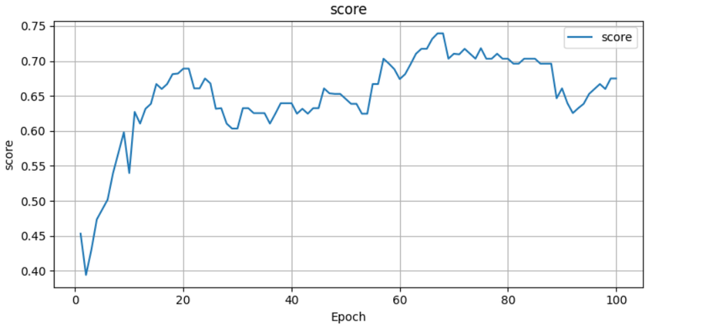

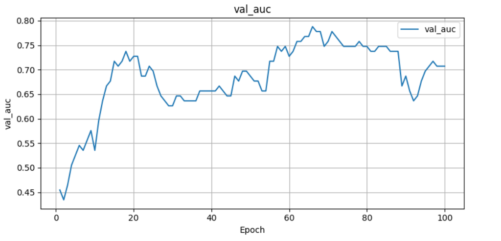

--2--

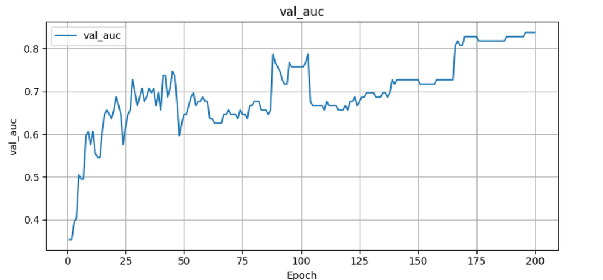

--3--

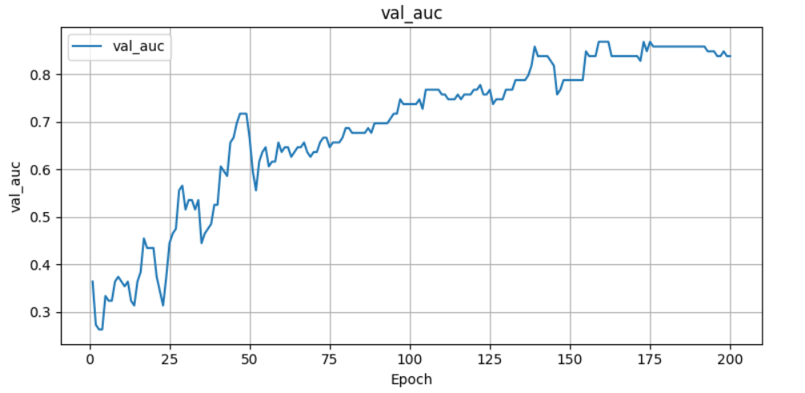

- 因为始终不能很好的收敛所以依赖初始化，因此保留了一些表现很好的模型
- 找到了，固定随机种子就可以让结果可复现，似乎仅限3位数可以完全一致
- 写了个run.py支持多重实验
- 目前的结果支持完全复现

### 2.4 version4.0 截止5.18

> 增加了粗糙的可视化和几类基线模型的基本改进：层次方法基本对齐，但基线auc还是挺低的 MSMESAGE逊于MSMEGAT
- 正式写作还需要：
  - 进一步优化可视化，需要复现一些解释性建议里的想法，最基本的扰动向量映射和图池化要做好
  - 需要结合人脑解剖图绘图
  - 添加xgb rf svm等ml模型

### 2.4 5.18 续

- 可以把重点放在扰动核与结构核上
- 解剖类别映射关系:

```
编码 0: Frontal
编码 1: Occipital
编码 2: Parietal
编码 3: Prefontal
编码 4: Subcortical
编码 5: Temporal
```

### 几类机器学习模型

> xgb rf svm

```python
import numpy as np
from sklearn.model_selection import train_test_split
from sklearn.preprocessing import StandardScaler
from sklearn.svm import SVC
from sklearn.ensemble import RandomForestClassifier
from sklearn.metrics import roc_auc_score
import xgboost as xgb

# 加载数据
data = np.load('final_MSME/processed_brain_data_dti.npy', allow_pickle=True).item()
A = data['A']  # 邻接矩阵 [n, 90, 90]
y = data['y'] - 1  # 标签减1，调整为从0开始

# 按行求和得到90维特征
features = np.sum(A, axis=2)  # 每个样本得到 [90] 维特征

# 划分训练集和测试集 (测试集比例为0.3)
X_train, X_test, y_train, y_test = train_test_split(
    features, y, test_size=0.3, random_state=42, stratify=y
)

# 标准化特征
scaler = StandardScaler()
X_train_scaled = scaler.fit_transform(X_train)
X_test_scaled = scaler.transform(X_test)

# 模型1: SVM 使用 RBF 核
svm_rbf = SVC(kernel='rbf', probability=True, gamma='auto', C=1.0)
svm_rbf.fit(X_train_scaled, y_train)
y_pred_proba_svm = svm_rbf.predict_proba(X_test_scaled)[:, 1]
auc_svm = roc_auc_score(y_test, y_pred_proba_svm)

# 模型2: 随机森林
rf = RandomForestClassifier(n_estimators=100, random_state=42)
rf.fit(X_train, y_train)
y_pred_proba_rf = rf.predict_proba(X_test)[:, 1]
auc_rf = roc_auc_score(y_test, y_pred_proba_rf)

# 模型3: XGBoost
xgb_model = xgb.XGBClassifier(objective='binary:logistic',
                             learning_rate=0.1,
                             n_estimators=100,
                             random_state=999)
xgb_model.fit(X_train, y_train)
y_pred_proba_xgb = xgb_model.predict_proba(X_test)[:, 1]
auc_xgb = roc_auc_score(y_test, y_pred_proba_xgb)

# 打印测试集上的AUC
print(f"SVM with RBF kernel AUC: {auc_svm:.4f}")
print(f"Random Forest AUC: {auc_rf:.4f}")
print(f"XGBoost AUC: {auc_xgb:.4f}")

# 输出最好的模型
best_auc = max(auc_svm, auc_rf, auc_xgb)
if best_auc == auc_svm:
    best_model = "SVM with RBF kernel"
elif best_auc == auc_rf:
    best_model = "Random Forest"
else:
    best_model = "XGBoost"

print(f"\n最佳模型是 {best_model}，测试集 AUC 为 {best_auc:.4f}")
```

```
SVM with RBF kernel AUC: 0.6417
Random Forest AUC: 0.6818
XGBoost AUC: 0.7513

最佳模型是 XGBoost，测试集 AUC 为 0.7513
```